# Project 2: Data Mining, Classification, Prediction

SDS322E

12/10/21

# Mining, Classification, Prediction

## David Yang dy4652

### Introduction

```r
library(tidyverse)
cards <- read_csv("cards.csv")
cards <- cards %>% filter(type == "MINION") %>% filter(!is.na(collectible)) %>%
    select(2:10) %>% mutate(isLegendary = rarity == "LEGENDARY") %>%
    select(-"text")
# any other code here
```

### Cluster Analysis

```r
library(cluster)
library(GGally)
pam_dat <- cards %>% select(cost, attack, health)
sil_width <- vector()
for (i in 2:10) {
    pam_fit <- pam(pam_dat, k = i)
    sil_width[i] <- pam_fit$silinfo$avg.width
}
sil_width[2]
```

```
## [1] 0.4488333
```

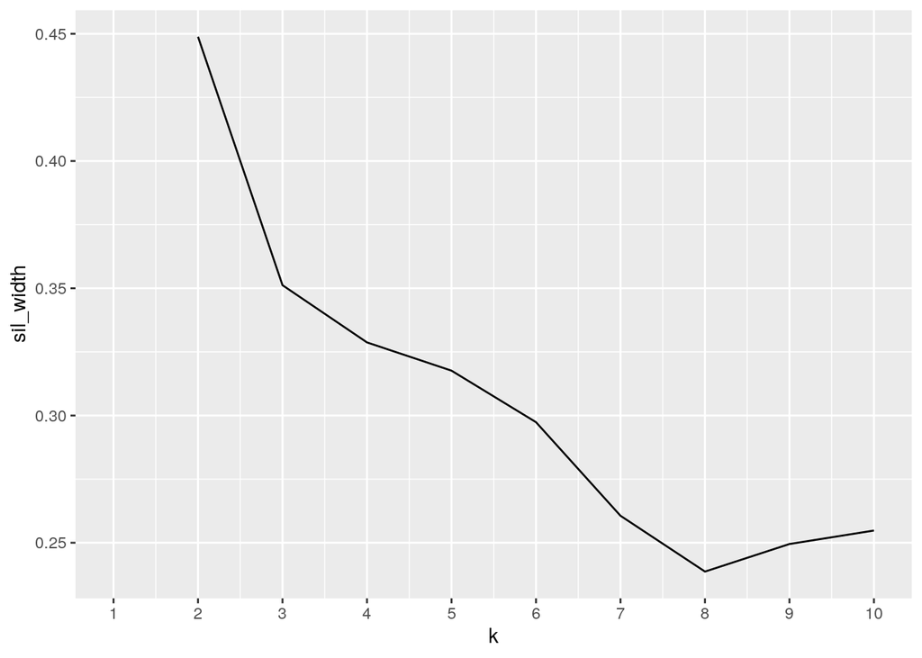

```r
ggplot() + geom_line(aes(x = 1:10, y = sil_width)) + scale_x_continuous(name = "k",
    breaks = 1:10)
```

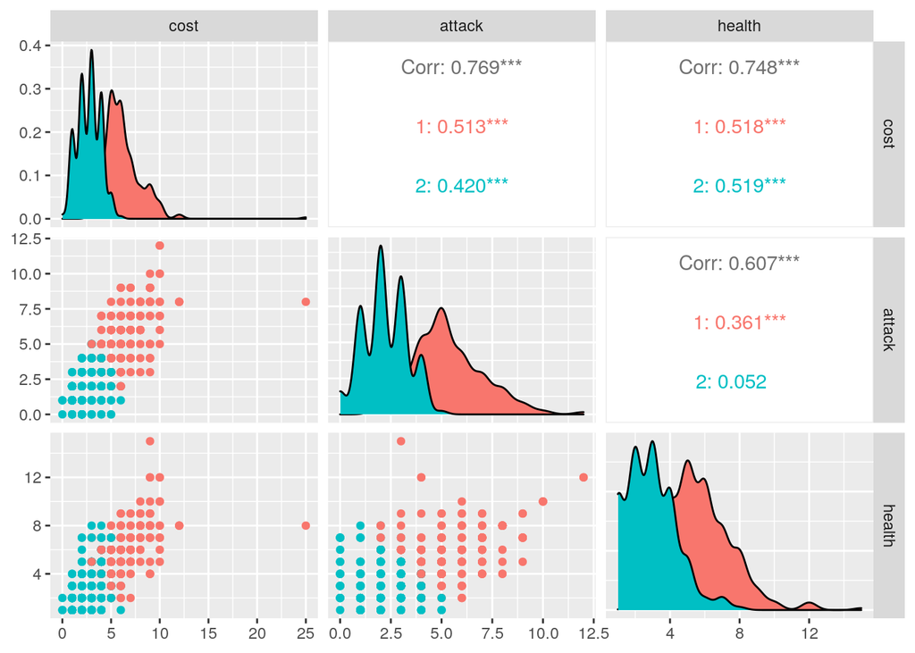

```r
pam1 <- pam_dat %>% pam(k = 2)
pamclust <- pam_dat %>% mutate(cluster = as.factor(pam1$clustering))
ggpairs(pamclust[1:3], aes(color = pamclust$cluster))
```

```r
pam1$medoids
```

```
##      cost attack health
## [1,]    6      5      5
## [2,]    3      2      3
```

The ideal cluster amount was found to be 2. The first cluster is centered around a cost of 6 mana, 5 attack, and 5 health. The second cluster is centered around a cost of 3 mana, 2 attack, and 3 health. There was a negative slope in the boundary between cost and the other 2 variables (with cost as the x-axis), meaning that cards with a relatively high cost but low attack/health would still be found in the first cluster (red) and vice versa. A negative slope can also be found in the cluster boundary between attack and health (attack as x-axis) so cards with a relatively low attack but relatively high health can be found in the first cluster (red) and vice versa. The clustering solution was not that good as the silhouette width for this solution was .449.

### Dimensionality Reduction with PCA

```r
cards_num <- cards %>% select_if(is.numeric) %>% scale
rownames(cards_num) <- cards$name
cards_pca <- princomp(cards_num)
summary(cards_pca, loadings = T)
```

```
## Importance of components:
##                           Comp.1    Comp.2     Comp.3
## Standard deviation     1.5538976 0.6271330 0.43359252
## Proportion of Variance 0.8059685 0.1312782 0.06275334
## Cumulative Proportion  0.8059685 0.9372467 1.00000000
##
## Loadings:
##        Comp.1 Comp.2 Comp.3
## cost    0.603         0.796
## attack  0.567  0.679 -0.466
## health  0.561 -0.733 -0.385
```

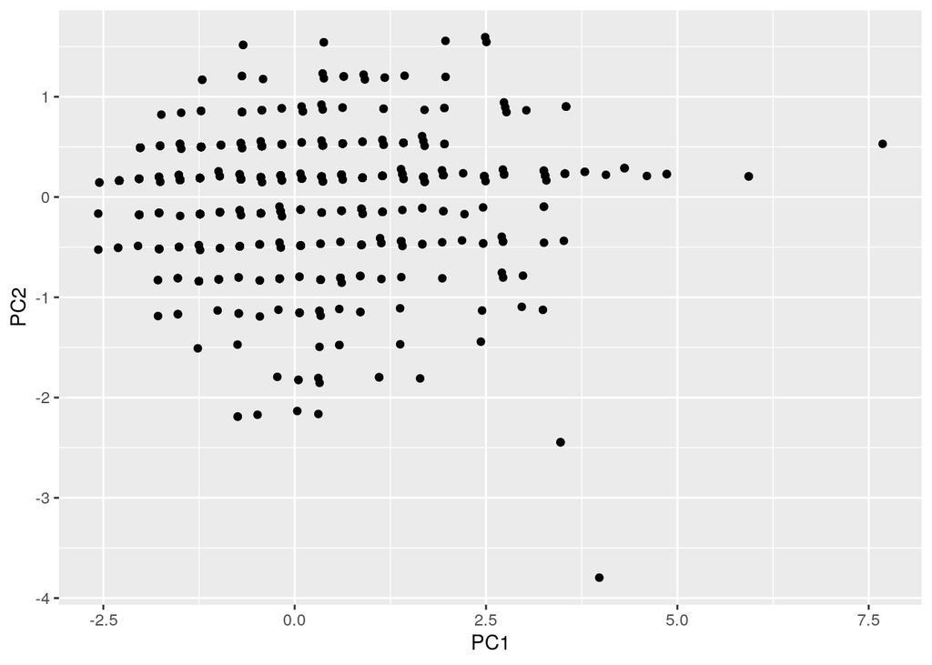

```r
cardsdf <- data.frame(PC1 = cards_pca$scores[, 1], PC2 = cards_pca$scores[,
    2])
ggplot(cardsdf, aes(PC1, PC2)) + geom_point()
```

The first PC accounts for about 80% of the variance. Scoring high on the PC1 means that the card has a high cost, attack, and health. Scoring low means that the card is low cost, attack, and health. The second PC accounts for 13% of the variance. Scoring high on PC2 means that the card has a high attack but low health. Scoring low on PC2 means that the card has a low attack but high health.

### Linear Classifier

```r
fit <- glm(isLegendary ~ cost + attack + health, data = cards,
    family = "binomial")
score <- predict(fit, type = "response")
score %>% round(3)
```

```
##     1     2     3     4     5     6     7     8     9    10    11    12    13
## 0.267 0.817 0.094 0.274 0.030 0.220 0.051 0.263 0.053 0.211 0.030 0.169 0.056
##    14    15    16    17    18    19    20    21    22    23    24    25    26
## 0.183 0.074 0.178 0.156 0.336 0.074 0.380 0.515 0.086 0.148 0.329 0.236 0.090
##    27    28    29    30    31    32    33    34    35    36    37    38    39
## 0.051 0.419 0.036 0.144 0.261 0.178 0.081 0.067 0.033 0.074 0.685 0.690 0.033
##    40    41    42    43    44    45    46    47    48    49    50    51    52
## 0.094 0.188 0.140 0.294 0.874 0.140 0.183 0.132 0.094 0.086 0.232 0.032 0.220
##    53    54    55    56    57    58    59    60    61    62    63    64    65
## 0.083 0.048 0.671 0.055 0.164 0.294 0.144 0.064 0.094 0.545 0.303 0.060 0.204
##    66    67    68    69    70    71    72    73    74    75    76    77    78
## 0.140 0.056 0.169 0.209 0.136 0.051 0.074 0.034 0.086 0.121 0.122 0.074 0.032
##    79    80    81    82    83    84    85    86    87    88    89    90    91
## 0.336 0.030 0.091 0.468 0.220 0.685 0.556 0.147 0.048 0.111 0.136 0.280 0.274
##    92    93    94    95    96    97    98    99   100
## 0.021 0.556 0.033 0.111 0.336 0.136 0.051 0.056 0.128
##  [ reached getOption("max.print") -- omitted 631 entries ]
```

```r
class_diag(score, truth = cards$isLegendary, positive = 1)
```

```
##            acc   sens   spec    ppv     f1     ba    auc
## Metrics 0.8427 0.2899 0.9713 0.7018 0.4103 0.6306 0.8052
```

```r
table(truth = cards$isLegendary, predictions = score > 0.5)
```

```
##        predictions
## truth   FALSE TRUE
##   FALSE   576   17
##   TRUE     98   40
```

```r
k = 10  #choose number of folds
data <- cards[sample(nrow(cards)), ]  #randomly order rows
folds <- cut(seq(1:nrow(cards)), breaks = k, labels = F)  #create folds
diags <- NULL
for (i in 1:k) {
    ## Create training and test sets
    train <- data[folds != i, ]
    test <- data[folds == i, ]
    truth <- test$isLegendary  ## Truth labels for fold i
    ## Train model on training set (all but fold i)
    fit <- glm(isLegendary ~ cost + attack + health, data = cards,
        family = "binomial")
    ## Test model on test set (fold i)
    probs <- predict(fit, newdata = test, type = "response")
    ## Get diagnostics for fold i
    diags <- rbind(diags, class_diag(probs, truth, positive = 1))
}

summarize_all(diags, mean)
```

```
##       acc   sens    spec     ppv      f1      ba     auc
## 1 0.84277 0.3018 0.97113 0.70186 0.40666 0.63647 0.81069
```

The logistic regression formula correlates positively with cost, attack, and health on determining whether or not a card is legendary. The AUC for the logistic regression model was .81 which makes it a pretty good predictor. The AUC after k-fold cross validation was about .80 which means that the model is not overfitting and can predict new observations quite well.

### Non-Parametric Classifier

```r
library(caret)
knn_fit <- knn3(isLegendary ~ attack + cost + health, data = cards)
y_hat_knn <- predict(knn_fit, cards)
class_diag(y_hat_knn[, 2], truth = cards$isLegendary, positive = "TRUE")
```

```
##            acc   sens   spec    ppv     f1     ba    auc
## Metrics 0.8591 0.3623 0.9747 0.7692 0.4926 0.6685 0.8755
```

```r
table(truth = cards$isLegendary, prediction = factor(y_hat_knn[,
    2] > 0.5, levels = c("FALSE", "TRUE")))
```

```
##        prediction
## truth   FALSE TRUE
##   FALSE   578   15
##   TRUE     88   50
```

```r
k = 10  #choose number of folds
data <- cards[sample(nrow(cards)), ]  #randomly order rows
folds <- cut(seq(1:nrow(cards)), breaks = k, labels = F)  #create folds
diags <- NULL
for (i in 1:k) {
    ## Create training and test sets
    train <- data[folds != i, ]
    test <- data[folds == i, ]
    truth <- test$isLegendary  ## Truth labels for fold i
    ## Train model on training set (all but fold i)
    fit <- knn3(isLegendary ~ cost + attack + health, data = cards)
    ## Test model on test set (fold i)
    probs <- predict(fit, newdata = test)
    ## Get diagnostics for fold i
    diags <- rbind(diags, class_diag(probs[, 2], truth, positive = 1))
}
summarize_all(diags, mean)
```

```
##      acc    sens   spec     ppv      f1     ba     auc
## 1 0.8591 0.37179 0.9748 0.79448 0.49574 0.6733 0.87796
```

The knn model has an AUC value of .88 meaning that it is a good classifier on whether or not a card is legendary. The AUC for the k-fold CV was .87 meaning that the model is not overfitting. The AUC value for the knn model is higher than the logistic regression model meaning using the knn model will provide more accurate classifications.

### Regression/Numeric Prediction

```r
fit <- lm(cost ~ rarity + playerClass, data = cards)
yhat <- predict(fit)
mean((cards$cost - yhat)^2)
```

```
## [1] 4.12517
```

```r
k = 10  #choose number of folds
data <- cards[sample(nrow(cards)), ]  #randomly order rows
folds <- cut(seq(1:nrow(cards)), breaks = k, labels = F)  #create folds
diags <- NULL
for (i in 1:k) {
    train <- data[folds != i, ]
    test <- data[folds == i, ]

    fit <- lm(cost ~ rarity + playerClass, data = train)

    yhat <- predict(fit, newdata = test)

    diags <- mean((test$cost - yhat)^2)
}
mean(diags)
```

```
## [1] 3.797079
```

### Python

```r
library(reticulate)
r_object <- 2
use_python("/usr/bin/python3", required = F)
```

```python
hello = 2
print(hello**r.r_object == 4)
```

```
## True
```

Discussion

### Concluding Remarks

It was a fun experiment. Initially I wanted to use another binary variable, but there were so many TRUE’s that the predictor models just predicted true always, but I do realize that the binary operator I did use was pretty similar to the pokemon dataset we did in class (detecting whether or not a pokemon was legendary).